# Classification For Models using Logistic Regression and Decision Tree

# Load Libraries

```r
library(dplyr)
```

```r
library(ggplot2)
library(rpart)
library(rpart.plot)
library(RColorBrewer)
library(caret)
```

**Read csv file in new dataframe**

```r
#Listings_Cleaned <- readRDS("data.Rda")
Listings_Cleaned <- read.csv("Data//CleanedListings.csv")
```

**Some Visualization to view variable importance to determine SuperHost/Not SuperHost()**

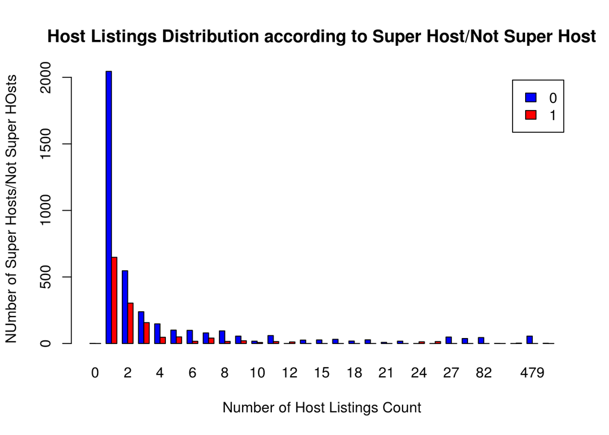

```r
tbl <- with(Listings_Cleaned, table(Listings_Cleaned$host_is_superhost, Listings_Cleaned$host_listings_count))
cols <- c("blue", "red")
barplot(tbl, beside = TRUE, legend = TRUE, col = cols,xlab="Number of Host Listings Count",ylab="NUmber of Super Hosts/Not Super HOsts", main="Host Listings Distribution according to Super Host/Not Super Host")
```

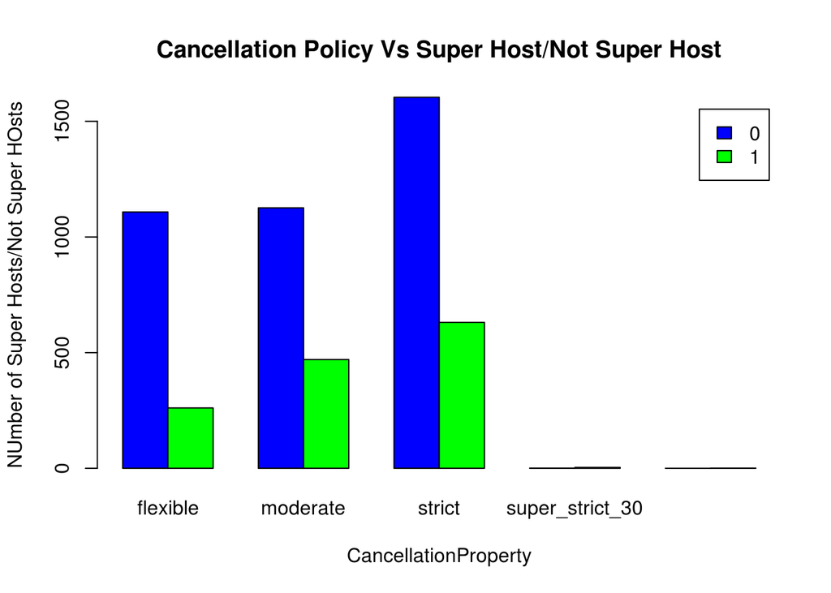

```r
tbl_Cancellation <- with(Listings_Cleaned, table(Listings_Cleaned$host_is_superhost, Listings_Cleaned$cancellation_policy))
cols <- c("blue", "green")
barplot(tbl_Cancellation, beside = TRUE, legend = TRUE, col = cols,xlab="CancellationProperty",ylab="NUmber of Super Hosts/Not Super HOsts", main="Cancellation Policy Vs Super Host/Not Super Host")
```

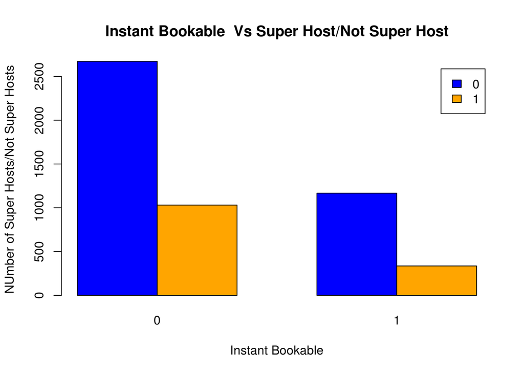

```r
tbl_instantBOokable <- with(Listings_Cleaned, table(Listings_Cleaned$host_is_superhost, Listings_Cleaned$instant_bookable))
cols <- c("blue", "orange")
barplot(tbl_instantBOokable, beside = TRUE, legend = TRUE, col = cols,xlab="Instant Bookable",ylab="NUmber of Super Hosts/Not Super Hosts", main="Instant Bookable  Vs Super Host/Not Super Host")
```

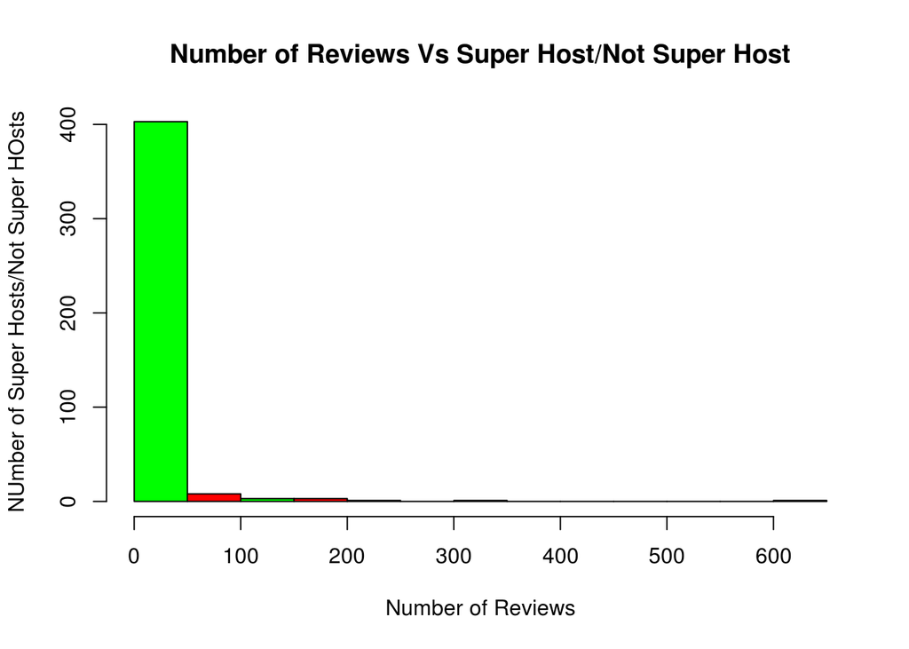

```r
tbl_reviews <- with(Listings_Cleaned, table(Listings_Cleaned$host_is_superhost, Listings_Cleaned$number_of_reviews))
cols <- c("green", "red")
hist(tbl_reviews, col = cols,xlab="Number of Reviews",ylab="NUmber of Super Hosts/Not Super HOsts", main="Number of Reviews Vs Super Host/Not Super Host")
```

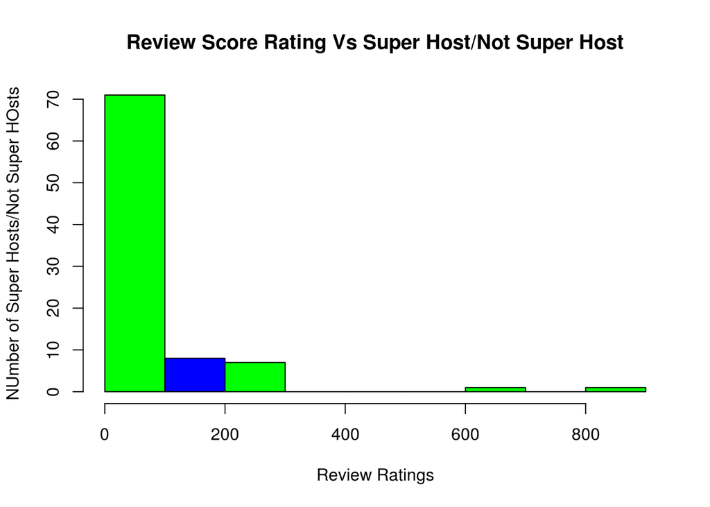

```r
tbl_reviews <- with(Listings_Cleaned, table(Listings_Cleaned$host_is_superhost, Listings_Cleaned$review_scores_rating))
cols <- c("green", "blue")
hist(tbl_reviews, col = cols,xlab="Review Ratings",ylab="NUmber of Super Hosts/Not Super HOsts", main="Review Score Rating Vs Super Host/Not Super Host")
```

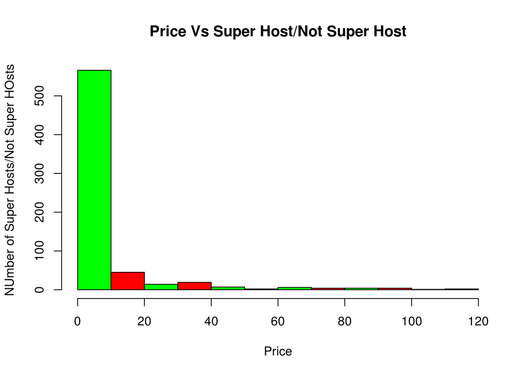

```r
tble_price <- with(Listings_Cleaned, table(Listings_Cleaned$host_is_superhost, Listings_Cleaned$price))
cols <- c("green", "red")
hist(tble_price, col = cols,xlab="Price",ylab="NUmber of Super Hosts/Not Super HOsts", main="Price Vs Super Host/Not Super Host")
```

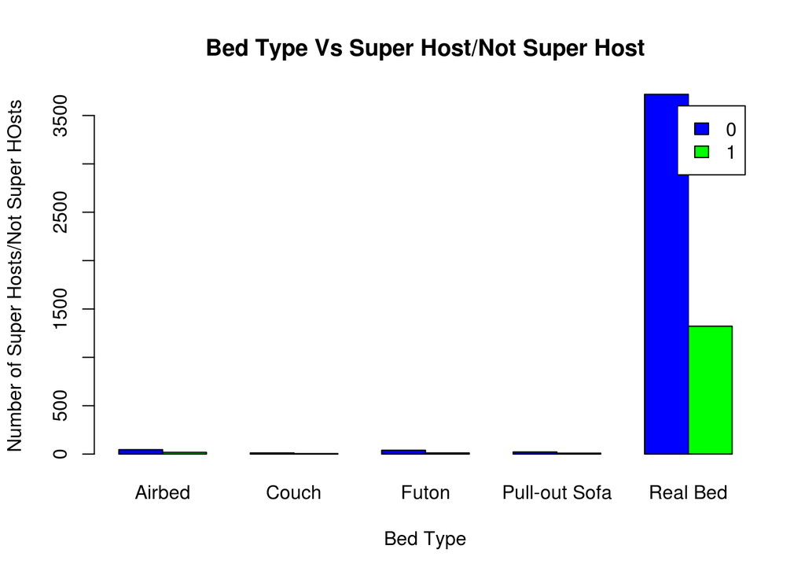

```r
tble_bedtype <- with(Listings_Cleaned, table(Listings_Cleaned$host_is_superhost, Listings_Cleaned$bed_type))
cols <- c("blue", "green")
barplot(tble_bedtype, beside = TRUE, legend = TRUE, col = cols,xlab="Bed Type",ylab="Number of Super Hosts/Not Super HOsts", main="Bed Type Vs Super Host/Not Super Host")
```

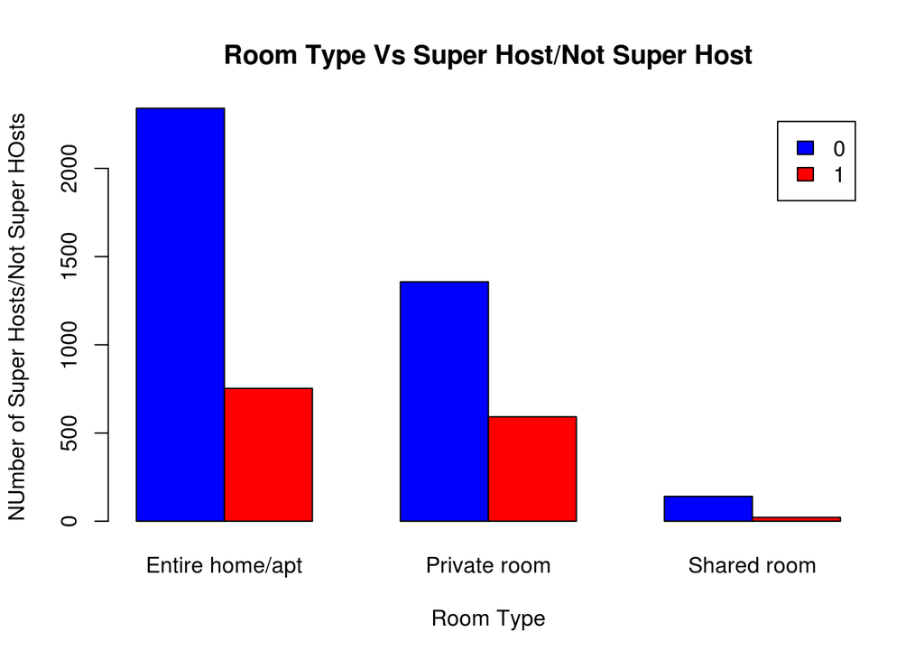

```r
table_roomtype <- with(Listings_Cleaned, table(Listings_Cleaned$host_is_superhost, Listings_Cleaned$room_type))
cols <- c("blue", "red")
barplot(table_roomtype, beside = TRUE, legend = TRUE, col = cols,xlab="Room Type",ylab="NUmber of Super Hosts/Not Super HOsts", main="Room Type Vs Super Host/Not Super Host")
```

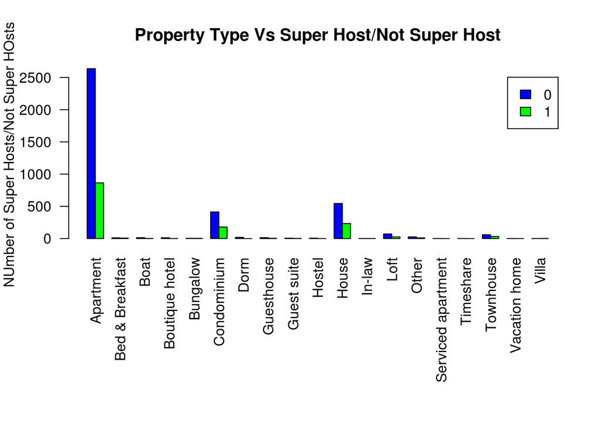

```r
table_propertyType <- with(Listings_Cleaned, table(Listings_Cleaned$host_is_superhost, Listings_Cleaned$property_type))
cols <- c("blue", "green")
op <- par(mar=c(11,4,4,2))
barplot(table_propertyType, beside = TRUE, legend = TRUE, col = cols,ylab="NUmber of Super Hosts/Not Super HOsts", main="Property Type Vs Super Host/Not Super Host",horiz=F, las=2)
```

```r
rm(op)
```

## Subset Data depending on some EDA and logical selection of variables

```r
# SubsetData <- Listings_Cleaned[c(12:16,18,30,31,36,38,51,54,57,55)]
# str(SubsetData)



SubsetData <- na.omit(Listings_Cleaned %>% select(host_response_time,host_response_rate,host_is_superhost,host_listings_count,host_total_listings_count,host_identity_verified,property_type,room_type,bed_type,price,number_of_reviews,review_scores_rating,calculated_host_listings_count,cancellation_policy,instant_bookable))
```

**Change proprty type column values to “Others” as the factors of property type were causing error in confusion matrix.Also these types do not influence the data more as we saw from Visualization of property type vs host**

```r
library(plyr)
revalue(SubsetData$property_type, c("Boat" = "Other")) -> SubsetData$property_type
revalue(SubsetData$property_type, c("Boutique hotel" = "Other")) -> SubsetData$property_type
revalue(SubsetData$property_type, c("Bungalow" = "Other")) -> SubsetData$property_type
revalue(SubsetData$property_type, c("Dorm" = "Other")) -> SubsetData$property_type
revalue(SubsetData$property_type, c("Guest suite" = "Other")) -> SubsetData$property_type
revalue(SubsetData$property_type, c("Hostel" = "Other")) -> SubsetData$property_type
revalue(SubsetData$property_type, c("In-law" = "Other")) -> SubsetData$property_type
revalue(SubsetData$property_type, c("Loft" = "Other")) -> SubsetData$property_type
revalue(SubsetData$property_type, c("Serviced apartment" = "Other")) -> SubsetData$property_type
revalue(SubsetData$property_type, c("Bed & Breakfast" = "Other")) -> SubsetData$property_type
revalue(SubsetData$property_type, c("Townhouse" = "Other")) -> SubsetData$property_type
revalue(SubsetData$property_type, c("Vacation home" = "Other")) -> SubsetData$property_type
```

**View Structure after changing property type Subset Data. Factor levels reduced to 7 levels**

```r
str(SubsetData$property_type)
```

```
##  Factor w/ 7 levels "Apartment","Other",..: 5 3 2 3 1 3 1 1 1 1 ...
```

```r
nlevels(SubsetData$property_type)
```

```
## [1] 7
```

**Change categorical types to factors**

```r
SubsetData$host_is_superhost <- as.factor(SubsetData$host_is_superhost)
SubsetData$instant_bookable <- as.factor(SubsetData$instant_bookable)
SubsetData$host_identity_verified <- as.factor(SubsetData$host_identity_verified)
```

**Divide Test and fit data**

```r
set.seed(1592)
testrecs <- sample(nrow(SubsetData),0.2 * nrow(SubsetData))
SubsetData_test <- SubsetData[testrecs,]
SubsetData_fit <- SubsetData[-testrecs,]
```

**Check factor levels of fit and test.Make sure they match**

```r
str(SubsetData_fit)
```

```
## 'data.frame':    4165 obs. of  15 variables:
##  $ host_response_time            : Factor w/ 5 levels "","a few days or more",..: 5 5 4 5 5 1 5 5 5 4 ...
##  $ host_response_rate            : num  100 100 100 100 100 ...
##  $ host_is_superhost             : Factor w/ 2 levels "0","1": 2 1 2 1 1 1 2 1 1 1 ...
##  $ host_listings_count           : int  1 3 1 3 1 1 2 1 2 1 ...
##  $ host_total_listings_count     : int  1 3 1 3 1 1 2 1 2 1 ...
##  $ host_identity_verified        : Factor w/ 2 levels "0","1": 2 2 2 2 2 2 2 2 2 2 ...
##  $ property_type                 : Factor w/ 7 levels "Apartment","Other",..: 5 3 3 3 1 1 1 1 5 1 ...
##  $ room_type                     : Factor w/ 3 levels "Entire home/apt",..: 2 2 2 2 2 2 1 1 1 1 ...
##  $ bed_type                      : Factor w/ 5 levels "Airbed","Couch",..: 5 5 5 5 3 5 5 5 5 3 ...
##  $ price                         : num  56 36 80 28 45 48 331 89 119 52 ...
##  $ number_of_reviews             : int  25 0 12 1 5 14 0 8 27 2 ...
##  $ review_scores_rating          : num  99 95 98 100 100 ...
##  $ calculated_host_listings_count: int  1 3 1 3 1 1 2 1 2 1 ...
##  $ cancellation_policy           : Factor w/ 5 levels "flexible","moderate",..: 2 3 1 3 1 1 2 3 3 3 ...
##  $ instant_bookable              : Factor w/ 2 levels "0","1": 2 2 1 2 1 1 2 1 1 1 ...
```

```r
str(SubsetData_test)
```

```
## 'data.frame':    1041 obs. of  15 variables:
##  $ host_response_time            : Factor w/ 5 levels "","a few days or more",..: 3 2 3 4 5 5 5 3 3 4 ...
##  $ host_response_rate            : num  83 33 50 100 100 100 80 79 100 94 ...
##  $ host_is_superhost             : Factor w/ 2 levels "0","1": 1 1 1 1 1 1 2 1 2 2 ...
##  $ host_listings_count           : int  2 1 1 1 1 1 2 1 2 1 ...
##  $ host_total_listings_count     : int  2 1 1 1 1 1 2 1 2 1 ...
##  $ host_identity_verified        : Factor w/ 2 levels "0","1": 1 1 1 2 1 1 2 2 2 1 ...
##  $ property_type                 : Factor w/ 7 levels "Apartment","Other",..: 1 1 1 3 1 2 1 1 5 1 ...
##  $ room_type                     : Factor w/ 3 levels "Entire home/apt",..: 2 2 1 1 2 1 3 1 1 1 ...
##  $ bed_type                      : Factor w/ 5 levels "Airbed","Couch",..: 5 5 5 5 5 5 4 5 5 5 ...
##  $ price                         : num  52 100 120 150 39 500 40 52 124 150 ...
##  $ number_of_reviews             : int  2 0 48 5 0 0 23 136 253 87 ...
##  $ review_scores_rating          : num  100 95 91 100 95 ...
##  $ calculated_host_listings_count: int  2 1 1 1 1 1 2 1 1 1 ...
##  $ cancellation_policy           : Factor w/ 5 levels "flexible","moderate",..: 2 1 3 1 1 1 2 2 2 2 ...
##  $ instant_bookable              : Factor w/ 2 levels "0","1": 1 1 2 1 1 1 2 1 1 1 ...
```

# Logistic Regression

*Run Logistic Regression*

```r
superhost_LogM1 <- glm(host_is_superhost ~  .,
                    data=SubsetData_fit, family=binomial(link="logit"))

summary(superhost_LogM1)
```

```
##
## Call:
## glm(formula = host_is_superhost ~ ., family = binomial(link = "logit"),
##     data = SubsetData_fit)
##
## Deviance Residuals:
##     Min       1Q   Median       3Q      Max
## -2.8448  -0.7550  -0.4008   0.6699   4.5052
##
## Coefficients: (1 not defined because of singularities)
##                                        Estimate Std. Error z value
## (Intercept)                          -3.098e+01  1.704e+00 -18.188
## host_response_timea few days or more -9.245e+00  2.573e+02  -0.036
## host_response_timewithin a day        1.099e+00  3.062e-01   3.590
## host_response_timewithin a few hours  1.308e+00  2.915e-01   4.486
## host_response_timewithin an hour      1.761e+00  2.828e-01   6.226
## host_response_rate                    4.683e-02  9.218e-03   5.080
## host_listings_count                   1.527e-04  2.248e-03   0.068
## host_total_listings_count                    NA         NA      NA
## host_identity_verified1               7.077e-01  1.154e-01   6.132
## property_typeOther                    1.789e-01  1.703e-01   1.051
## property_typeCondominium              8.556e-02  1.267e-01   0.675
## property_typeGuesthouse              -2.261e-01  6.300e-01  -0.359
## property_typeHouse                    2.015e-02  1.161e-01   0.174
## property_typeTimeshare               -1.355e+01  1.455e+03  -0.009
## property_typeVilla                    1.667e+01  9.762e+02   0.017
## room_typePrivate room                 2.434e-01  9.396e-02   2.591
## room_typeShared room                 -5.542e-01  3.406e-01  -1.627
## bed_typeCouch                         3.010e-01  7.983e-01   0.377
## bed_typeFuton                        -6.770e-01  5.559e-01  -1.218
## bed_typePull-out Sofa                -2.240e-01  6.434e-01  -0.348
## bed_typeReal Bed                     -3.225e-01  3.942e-01  -0.818
## price                                -4.372e-04  3.492e-04  -1.252
## number_of_reviews                     1.393e-02  1.142e-03  12.196
## review_scores_rating                  2.406e-01  1.420e-02  16.946
## calculated_host_listings_count       -4.472e-02  1.136e-02  -3.938
## cancellation_policymoderate           1.876e-01  1.126e-01   1.666
## cancellation_policystrict             3.204e-01  1.086e-01   2.949
## cancellation_policysuper_strict_30    1.642e+00  1.165e+00   1.409
## cancellation_policysuper_strict_60    1.561e+01  1.455e+03   0.011
```

[output cut: 27 more lines]

```
## cancellation_policymoderate          0.095705 .
## cancellation_policystrict            0.003192 **
## cancellation_policysuper_strict_30   0.158728
## cancellation_policysuper_strict_60   0.991443
## instant_bookable1                    0.000234 ***
## ---
## Signif. codes:  0 '***' 0.001 '**' 0.01 '*' 0.05 '.' 0.1 ' ' 1
##
## (Dispersion parameter for binomial family taken to be 1)
##
##     Null deviance: 4792.5  on 4164  degrees of freedom
## Residual deviance: 3758.2  on 4136  degrees of freedom
## AIC: 3816.2
##
## Number of Fisher Scoring iterations: 14
```

**Convert FItted values to predictions**

```r
Pred_LogM1 <- (superhost_LogM1$fit > 0.5) * 1
```

**Take Actual and Predicted toghther for easy interpretation**

```r
Host_Super_Host_fit_predictions <- data.frame(superhost_LogM1$y, Pred_LogM1)
names(Host_Super_Host_fit_predictions) <- c("Actual","Pred_LogM1")
```

**Table for Predicted vs Actual for Logistic**

```r
table(Host_Super_Host_fit_predictions$Actual, Host_Super_Host_fit_predictions$Pred_LogM1)
```

```
##
##        0    1
##   0 2834  239
##   1  681  411
```

**Confusion metrics and statistics for LOgistic**

```r
cm_LogM1 <- confusionMatrix(Host_Super_Host_fit_predictions$Pred_LogM1, Host_Super_Host_fit_predictions$Actual,
                            positive = "1")
```

**Libraries for Decision Trees**

```r
library(rpart)
library(rpart.plot)
library(RColorBrewer)
```

# Decision Tree

**Run Decision Tree**

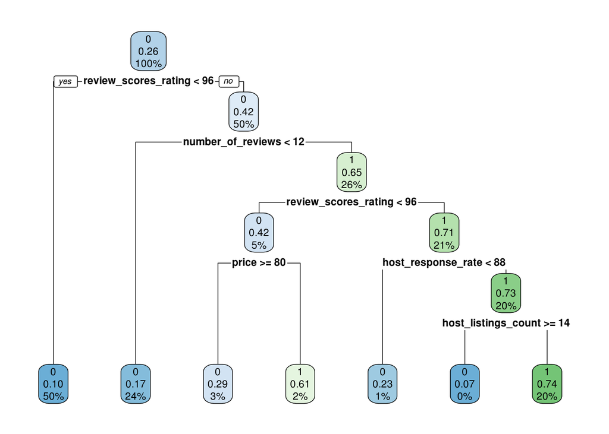

```r
host_super_host_tree1 <- rpart(host_is_superhost ~ ., data=SubsetData_fit, method="class")
# Visualize the tree with rpart.plot
rpart.plot(host_super_host_tree1)
```

**Table of actual and predicted Decision Tree**

```r
Host_Super_Host_fit_predictions$Pred_tree1 <- predict(host_super_host_tree1, type = "class")

table(Host_Super_Host_fit_predictions$Actual, Host_Super_Host_fit_predictions$Pred_tree1)
```

```
##
##        0    1
##   0 2820  253
##   1  424  668
```

**Confusion Metrics for Decision tree**

```r
cm_tree1 <- confusionMatrix(Host_Super_Host_fit_predictions$Pred_tree1, Host_Super_Host_fit_predictions$Actual,
                            positive = "1")
cm_tree1
```

```
## Confusion Matrix and Statistics
##
##           Reference
## Prediction    0    1
##          0 2820  424
##          1  253  668
##
##                Accuracy : 0.8375
##                  95% CI : (0.8259, 0.8485)
##     No Information Rate : 0.7378
##     P-Value [Acc > NIR] : < 2.2e-16
##
##                   Kappa : 0.5575
##  Mcnemar's Test P-Value : 6.419e-11
##
##             Sensitivity : 0.6117
##             Specificity : 0.9177
##          Pos Pred Value : 0.7253
##          Neg Pred Value : 0.8693
##              Prevalence : 0.2622
##          Detection Rate : 0.1604
##    Detection Prevalence : 0.2211
##       Balanced Accuracy : 0.7647
##
##        'Positive' Class : 1
##
```

**Predictions using Logistic and Decision trees**

```r
Predictions_Final <- predict(superhost_LogM1, newdata=SubsetData_test, type="response")
Predictions_Final <- (Predictions_Final > 0.5) * 1
head(Predictions_Final)
```

```
##  840  114 2695 1132 4346 2202
##    0    0    0    0    0    0
```

**show the prediction first row**

```r
prob_LogLM1 <- predict(superhost_LogM1, newdata=SubsetData_test, type="response")
pred_LogLM1 <- (prob_LogLM1 > 0.5) * 1
head(pred_LogLM1)
```

```
##  840  114 2695 1132 4346 2202
##    0    0    0    0    0    0
```

**Predictions using Decision tree**

```r
pred_tree1 <- predict(host_super_host_tree1, newdata=SubsetData_test, type="class")
head(pred_tree1)
```

```
##  840  114 2695 1132 4346 2202
##    0    0    0    0    0    0
## Levels: 0 1
```

**Prediction Data Table**

```r
Predictions_Data <- as.data.frame(cbind(Predictions_Final,
                                    pred_tree1, SubsetData_test$host_is_superhost))
names(Predictions_Data) <- c("pred_LogLM1", "pred_tree1", "Test_Is_Host_Super_Host")
tail(Predictions_Data)
```

```
##      pred_LogLM1 pred_tree1 Test_Is_Host_Super_Host
## 4242           1          2                       2
## 4251           0          1                       1
## 1054           0          2                       2
## 41             1          2                       2
## 5081           0          1                       1
## 1044           0          1                       1
```

**Change the mapping to match actual factor levels**

```r
Predictions_Data$Test_Is_Host_Super_Host <- Predictions_Data$Test_Is_Host_Super_Host -1
Predictions_Data$pred_tree1 <- Predictions_Data$pred_tree1 -1
# levels(Predictions_Data$Test_Is_Host_Super_Host) <- list("0" = "1", "1" = "2")
# levels(Predictions_Data$pred_LogLM1) <- list("0" = "1", "1" = "2")
# levels(Predictions_Data$pred_tree1) <- list("0" = "1", "1" = "2")
str(Predictions_Data)
```

```
## 'data.frame':    1041 obs. of  3 variables:
##  $ pred_LogLM1            : num  0 0 0 0 0 0 0 0 1 0 ...
##  $ pred_tree1             : num  0 0 0 0 0 0 0 1 1 1 ...
##  $ Test_Is_Host_Super_Host: num  0 0 0 0 0 0 1 0 1 1 ...
```

**Change to factors**

```r
Predictions_Data$Test_Is_Host_Super_Host <- as.factor(Predictions_Data$Test_Is_Host_Super_Host)
Predictions_Data$pred_tree1 <- as.factor(Predictions_Data$pred_tree1)
Predictions_Data$pred_LogLM1 <- as.factor(Predictions_Data$pred_LogLM1)
str(Predictions_Data)
```

```
## 'data.frame':    1041 obs. of  3 variables:
##  $ pred_LogLM1            : Factor w/ 2 levels "0","1": 1 1 1 1 1 1 1 1 2 1 ...
##  $ pred_tree1             : Factor w/ 2 levels "0","1": 1 1 1 1 1 1 1 2 2 2 ...
##  $ Test_Is_Host_Super_Host: Factor w/ 2 levels "0","1": 1 1 1 1 1 1 2 1 2 2 ...
```

**Confusion Matrix for Logistic**

```r
cm_predLogM1 <- confusionMatrix(Predictions_Data$pred_LogLM1,
                                Predictions_Data$Test_Is_Host_Super_Host,
                                positive = "1")
cm_predLogM1
```

```
## Confusion Matrix and Statistics
##
##           Reference
## Prediction   0   1
##          0 697 167
##          1  69 108
##
##                Accuracy : 0.7733
##                  95% CI : (0.7466, 0.7984)
##     No Information Rate : 0.7358
##     P-Value [Acc > NIR] : 0.00303
##
##                   Kappa : 0.3417
##  Mcnemar's Test P-Value : 2.716e-10
##
##             Sensitivity : 0.3927
##             Specificity : 0.9099
##          Pos Pred Value : 0.6102
##          Neg Pred Value : 0.8067
##              Prevalence : 0.2642
##          Detection Rate : 0.1037
##    Detection Prevalence : 0.1700
##       Balanced Accuracy : 0.6513
##
##        'Positive' Class : 1
##
```

**Confusion Matrix for Decision Tree**

```r
cm_predTRee <- confusionMatrix(Predictions_Data$pred_tree1,
                                Predictions_Data$Test_Is_Host_Super_Host)
cm_predTRee
```

```
## Confusion Matrix and Statistics
##
##           Reference
## Prediction   0   1
##          0 678 118
##          1  88 157
##
##                Accuracy : 0.8021
##                  95% CI : (0.7766, 0.8259)
##     No Information Rate : 0.7358
##     P-Value [Acc > NIR] : 3.569e-07
##
##                   Kappa : 0.4725
##  Mcnemar's Test P-Value : 0.04333
##
##             Sensitivity : 0.8851
##             Specificity : 0.5709
##          Pos Pred Value : 0.8518
##          Neg Pred Value : 0.6408
##              Prevalence : 0.7358
##          Detection Rate : 0.6513
##    Detection Prevalence : 0.7646
##       Balanced Accuracy : 0.7280
##
##        'Positive' Class : 0
##
```

**Summary Matrix**

```r
Model <- c('Logistic','BinaryTree')

Train_Accuracy <- c(cm_LogM1$overall[1],cm_tree1$overall[1])

Test_Accuracy <- c(cm_predLogM1$overall[1],cm_predTRee$overall[1])

Accuracy_Summary <- data.frame(Model,Train_Accuracy,Test_Accuracy)

Accuracy_Summary
```

```
##        Model Train_Accuracy Test_Accuracy
## 1   Logistic      0.7791116     0.7732949
## 2 BinaryTree      0.8374550     0.8021134
```

# Overall Summary

**Decision Tree performed better then logistic regression with overall accuracy of 0.8 both on Train and Test data. Logistic on the other hand performed with accuracy of 0.7 for both test and train data . So clearly, Decision TRee perfroms better then Logistic**